# Download and Prepare PNADC Data

## Introduction

This vignette provides a complete, step-by-step workflow for downloading Brazil’s quarterly PNADC (Pesquisa Nacional por Amostra de Domicilios Continua) survey data and preparing it for mensalization. By the end, you will have monthly reference months identified for each survey observation and optionally computed monthly survey weights.

The workflow covers three main tasks:

1. **Downloading** quarterly PNADC microdata from IBGE using the `PNADcIBGE` package
2. **Stacking** multiple quarters into a single dataset (critical for high determination rates)
3. **Applying mensalization** using the `mensalizePNADC` package

If you already have PNADC data and want to learn the package API first, see Get Started. For algorithm details, see How mensalizePNADC Works.

## Prerequisites

### Required Packages

```r
# Install packages if needed
install.packages(c("PNADcIBGE", "tidyverse", "fst"))

# Install mensalizePNADC from GitHub
# install.packages("remotes")
# remotes::install_github("antrologos/mensalizePNADC")

# Load packages
library(PNADcIBGE)
library(tidyverse)
library(fst)
library(mensalizePNADC)
```

### System Requirements

- **Disk space**: ~5 GB for 2020-2024 data, ~15 GB for full history (2012-present)
- **RAM**: At least 8 GB recommended; 16 GB for comfortable processing
- **Time**: 2-3 hours for downloading (depends on internet speed), ~5 minutes for processing
- **Internet**: Required for downloading data and for SIDRA API access (weight calibration)

## Understanding PNADC Data

PNADC is Brazil’s primary household survey for labor market statistics, conducted by IBGE. The survey uses a rotating panel design where each household is interviewed five times over 15 months. Each quarterly release contains approximately 500,000 observations.

**Why stack multiple quarters?** The mensalization algorithm identifies reference months by tracking households across their panel interviews. With a single quarter, the determination rate is only ~65-75%. By stacking multiple quarters, the algorithm can leverage the rotating panel structure to achieve a **97% determination rate**.

The figure below shows how determination rate improves as more quarters are stacked:

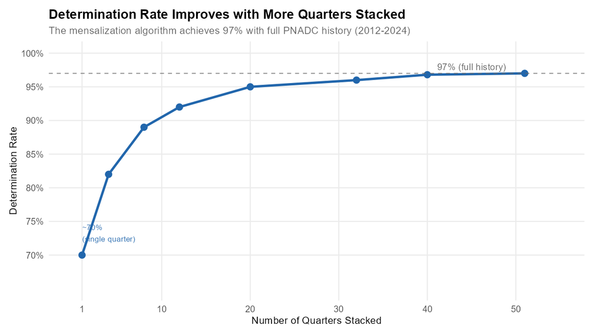

Determination rate improves with more stacked quarters

For most applications, we recommend stacking at least 2-3 years of data to achieve optimal results.

## Step 1: Set Up Your Environment

First, create a directory to store the downloaded data:

```r
# Set your data directory (adjust path as needed)
data_dir <- "path/to/your/pnadc_data/"

# Create directory if it doesn't exist
dir.create(data_dir, recursive = TRUE, showWarnings = FALSE)
```

## Step 2: Define Which Quarters to Download

Create a grid of year-quarter combinations to download. This example uses 2020-2024, which provides a good balance between data size and determination rate:

```r
# Define quarters to download (2020-2024 example)
editions <- expand.grid(
  year = 2020:2024,
  quarter = 1:4
) |>
  # Remove quarters not yet available
  filter(!(year == 2024 & quarter > 3))

# View the grid
editions
```

This creates a grid of 19 quarters. Adjust the filter for the most recent available quarter.

## Step 3: Download the Data

The download loop fetches each quarter from IBGE and saves it in FST format for fast loading later:

```r
# Download and save each quarter
for (i in 1:nrow(editions)) {
  year_i <- editions$year[i]
  quarter_i <- editions$quarter[i]

  filename <- paste0("pnadc_", year_i, "-", quarter_i, "q.fst")

  cat("Downloading:", year_i, "Q", quarter_i, "\n")

  # Download from IBGE
  pnadc_quarter <- get_pnadc(
    year = year_i,
    quarter = quarter_i,
    labels = FALSE,    # IMPORTANT: Use numeric codes, not labels
    deflator = FALSE,
    design = FALSE,
    savedir = data_dir
  )

  # Save as FST format (fast serialization)
  write_fst(pnadc_quarter, file.path(data_dir, filename))

  # Clean up temporary files created by PNADcIBGE
  temp_files <- list.files(data_dir,
                           pattern = "\\.(zip|sas|txt)$",
                           full.names = TRUE)
  file.remove(temp_files)

  # Free memory
  rm(pnadc_quarter)
  gc()
}
```

> **Important**: Always use `labels = FALSE` when downloading. The mensalization algorithm requires numeric codes for the birthday variables (V2008, V20081, V20082). Using labeled factors will cause errors.

This loop will take 2-3 hours depending on your internet connection. Each quarter is approximately 300-400 MB when saved as FST.

## Step 4: Stack the Quarterly Files

Now stack all the quarterly files into a single dataset. To save memory, we only load the columns needed for mensalization:

```r
# Columns needed for mensalization
cols_needed <- c(
  # Time and identifiers
  "Ano", "Trimestre", "UPA", "V1008", "V1014", "V2003",
  # Birthday variables (for reference month algorithm)
  "V2008", "V20081", "V20082", "V2009",
  # Weight and stratification (for weight calibration)
  "V1028", "UF", "posest", "posest_sxi"
)

# Stack all quarters
pnadc_stacked <- NULL

for (i in 1:nrow(editions)) {
  year_i <- editions$year[i]
  quarter_i <- editions$quarter[i]

  filename <- paste0("pnadc_", year_i, "-", quarter_i, "q.fst")
  cat("Loading:", filename, "\n")

  # Read only the columns we need (saves memory)
  quarter_data <- read_fst(
    file.path(data_dir, filename),
    columns = cols_needed
  )

  pnadc_stacked <- bind_rows(pnadc_stacked, quarter_data)
  rm(quarter_data)
  gc()
}

cat("Total observations:", format(nrow(pnadc_stacked), big.mark = ","), "\n")
```

Expected output:

```
Loading: pnadc_2020-1q.fst
Loading: pnadc_2020-2q.fst
...
Loading: pnadc_2024-3q.fst
Total observations: 10,847,562
```

## Step 5: Apply Mensalization

Now apply the mensalization algorithm. Setting `compute_weights = TRUE` also generates monthly survey weights:

```r
# Apply mensalization with monthly weight computation
result <- mensalizePNADC(
  data = pnadc_stacked,
  compute_weights = TRUE,
  verbose = TRUE
)

# Check the determination rate
cat("Determination rate:",
    sprintf("%.1f%%", attr(result, "determination_rate") * 100), "\n")
```

Expected output:

```
Validating input data...
Identifying reference months...
Computing monthly weights...
Fetching monthly population from SIDRA...
Calibrating weights...

Determination rate: 97.0%
```

## Step 6: Explore the Results

The result is a data.table with several new columns:

```r
# View the result structure
glimpse(result)

# Summary of reference month distribution
result |>
  count(ref_month_in_quarter) |>
  mutate(pct = n / sum(n) * 100)
```

Expected output:

```
# A tibble: 4 x 3
  ref_month_in_quarter       n   pct
                 <int>   <int> <dbl>
1                    1 3516234  32.4
2                    2 3498721  32.3
3                    3 3508234  32.3
4                   NA  324373   3.0
```

The output columns include:

| Column | Description |
| --- | --- |
| `ref_month` | Reference month as Date (first day of month) |
| `ref_month_in_quarter` | Position within quarter (1, 2, or 3) |
| `ref_month_yyyymm` | Reference month as YYYYMM integer |
| `weight_monthly` | Monthly survey weight (if `compute_weights = TRUE`) |

Observations with `ref_month_in_quarter = NA` have indeterminate reference months and should be excluded from monthly analyses.

## Step 7: Save and Use the Results

Save the mensalized data for future use:

```r
# Save the mensalized crosswalk
write_fst(result, file.path(data_dir, "pnadc_mensalized.fst"))
```

To use the results in analysis, join the mensalization crosswalk with your full PNADC data:

```r
# Load a quarterly file with all variables
full_data <- read_fst(file.path(data_dir, "pnadc_2023-1q.fst"))

# Join with mensalization results
analysis_data <- full_data |>
  left_join(
    result |> select(Ano, Trimestre, UPA, V1008, V1014, V2003,
                     ref_month, ref_month_in_quarter, weight_monthly),
    by = c("Ano", "Trimestre", "UPA", "V1008", "V1014", "V2003")
  )

# Now you can aggregate by month using weight_monthly
monthly_unemployment <- analysis_data |>
  filter(!is.na(ref_month_in_quarter)) |>
  group_by(ref_month) |>
  summarize(
    unemployment_rate = sum((VD4002 == 2) * weight_monthly, na.rm = TRUE) /
                        sum((VD4001 == 1) * weight_monthly, na.rm = TRUE)
  )
```

## Memory and Performance Tips

Working with PNADC microdata can be memory-intensive. Here are some tips:

1. **Selective column loading**: Only load the columns you need with `read_fst(..., columns = ...)`. This dramatically reduces memory usage.
2. **Process in batches**: For very large analyses, process one year at a time and combine results.
3. **Use FST format**: FST is much faster than CSV or RDS for large datasets. A typical quarter loads in seconds rather than minutes.
4. **Clean up regularly**: Use `rm()` and `gc()` to free memory after processing each quarter.

### File Size Reference

| Period | Quarters | Observations | FST Size |
| --- | --- | --- | --- |
| 2020-2024 | 19 | ~10.8M | ~5 GB |
| 2012-2024 | 51 | ~28.4M | ~15 GB |

## Extending to Full History

For the best determination rate and longitudinal analysis, download all available quarters:

```r
# Download all available data (2012-present)
editions_full <- expand.grid(
  year = 2012:2025,
  quarter = 1:4
) |>
  filter(!(year == 2025 & quarter > 3))  # Adjust for latest available

# Use the same download and stacking loops as above
```

The full history provides approximately 28 million observations and achieves the highest possible determination rate.

## Troubleshooting

### Common Issues

1. **“Column not found” errors**: Ensure you used `labels = FALSE` when downloading. The algorithm requires numeric codes.
2. **Download failures**: IBGE servers can be slow or unavailable. The `PNADcIBGE` package will retry automatically, but you may need to restart interrupted downloads.
3. **Memory errors**: Try processing fewer quarters at a time, or use a machine with more RAM.
4. **SIDRA API errors**: The weight calibration requires internet access to the SIDRA API. If it fails, try again later or use `compute_weights = FALSE` for just reference month identification.

## Next Steps

Now that you have mensalized PNADC data, you can:

- Follow the usage patterns in Get Started with your real data
- See analysis examples in Applied Examples
- Learn about the algorithm in How mensalizePNADC Works
- Visit the [package website](https://antrologos.github.io/mensalizePNADC/) for more resources

> **Working with annual PNADC data?** Annual data (visit-specific microdata with comprehensive income variables) requires a different workflow. See Monthly Poverty Analysis with Annual PNADC Data for details on using `mensalize_annual_pnadc()`.

For questions or issues, please open an issue on [GitHub](https://github.com/antrologos/mensalizePNADC/issues).